# Analyses on cases with two or more measuements

Author

Hanne Oberman

Published

February 28, 2025

This document contains the multilevel analyses to explain the variability in the outcome measure ‘trust in the government’ during the COVID pandemic. In these analyses, only cases with two or more measurements are included.

# Setup

## Packages and functions used

```r
# set random number generator
set.seed(11)

# setup environment
library(dplyr)      # Data wrangling improved
library(mice)       # For incomplete data analysis
library(miceadds)   # Additions to mice
library(ggmice)     # Plotting device for mice
library(lme4)       # Linear mixed-effect modeling
library(magrittr)   # Pipes in R
library(broom.mixed)# tidy and glance models for mixed effects classes
library(purrr)      # functional programming
library(ggplot2)
options(scipen = 999)
```

## Read in the incomplete data

Import the weighted data.

```r
dat_incomplete <- haven::read_sav("../Data/Alle metingen_lang bestand_REWEIGHTED_toshare_240814.sav") |>
  filter(gewogen == "ja")
ids_incomplete <- unique(dat_incomplete$id)
```

Import the imputed data.

```r
load("../Data/imp_post.RData")
```

## Filter cases with 2+ measurements

Find cases who had two or more measurements observed *before* imputation.

```r
ids_two_measurements <- imp_post$data[rowSums(is.na(imp_post$data)) < 10, ] %>%
  group_by(id) %>%
  summarise(n = n()) %>%
  filter(n > 1) %>%
  .$id
```

Subset the data to only include cases with two or more measurements and convert time from months to years.

```r
imp_jr <- imp_post %>%
  mice::complete(., "all") %>%
  map(., function(.x){
    mutate(.x, time_jr = meting_mnd/12) %>%
    filter(id %in% ids_two_measurements)
    })
```

# Compare descriptives

Select relevant demographic variables.

```r
full_sample <- mice::complete(imp_post)[, c("meting_mnd", "sekse", "age", "etn_herkomst", "edu", "q60_1")] |>
  filter(meting_mnd == 0)
subset <- imp_jr[[1]][, c("meting_mnd", "sekse", "age", "etn_herkomst", "edu", "q60_1")] |>
  filter(meting_mnd == 0)
```

Convert age into categories.

```r
# full sample
full_sample$age_cat <- NA
full_sample[full_sample$age < 35, "age_cat"] <- "18-34"
full_sample[full_sample$age >= 35 & full_sample$age < 50, "age_cat"] <- "35-49"
full_sample[full_sample$age >= 50 & full_sample$age < 65, "age_cat"] <- "50-64"
full_sample[full_sample$age >= 65, "age_cat"] <- "65+"
full_sample$age_cat <- factor(full_sample$age_cat, levels = c("18-34", "35-49", "50-64", "65+"))
# subset
subset$age_cat <- NA
subset[subset$age < 35, "age_cat"] <- "18-34"
subset[subset$age >= 35 & subset$age < 50, "age_cat"] <- "35-49"
subset[subset$age >= 50 & subset$age < 65, "age_cat"] <- "50-64"
subset[subset$age >= 65, "age_cat"] <- "65+"
subset$age_cat <- factor(subset$age_cat, levels = c("18-34", "35-49", "50-64", "65+"))
```

Compute summary stats per variable.

```r
dat_plot <- rbind(
  cbind(set = "full sample", full_sample),
  cbind(set = "subset", subset))
```

Sex.

```r
data.frame(rbind(summary(full_sample$sekse), summary(subset$sekse))) |> knitr::kable()
```

| Man | Vrouw |
| --- | --- |
| 29190 | 21283 |
| 13675 | 8395 |

```r
table(full_sample$sekse)/nrow(full_sample)
```

```
     Man    Vrouw
0.578329 0.421671
```

```r
table(subset$sekse)/nrow(subset)
```

```
      Man     Vrouw
0.6196194 0.3803806
```

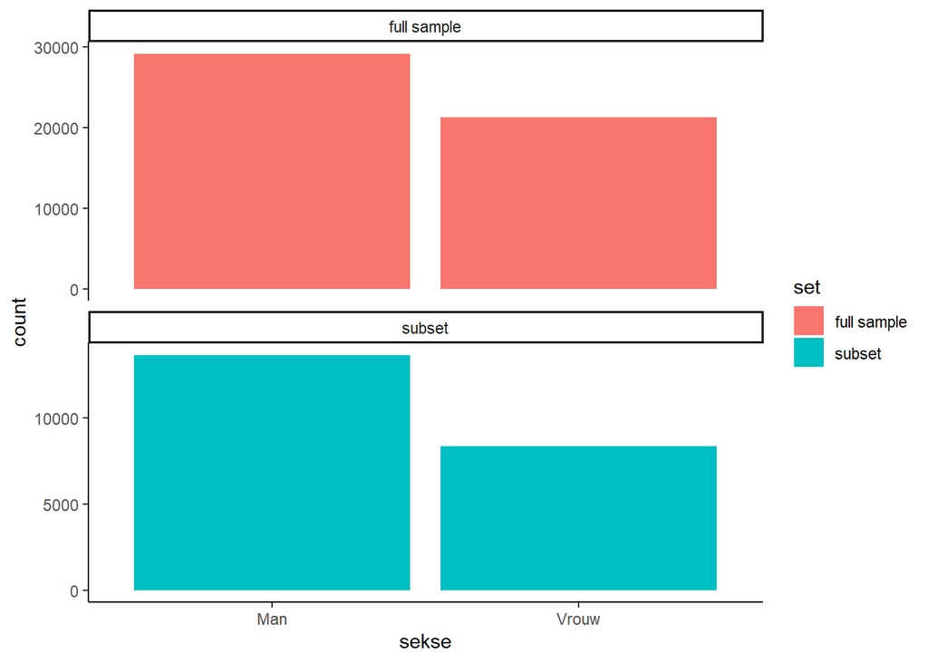

```r
ggplot(dat_plot, aes(x = sekse, fill = set)) +
  geom_bar() +
  facet_wrap(~set, ncol = 1, scales = "free_y") +
  theme_classic()
```

Age.

```r
data.frame(rbind(summary(full_sample$age_cat), summary(subset$age_cat))) |> knitr::kable()
```

| X18.34 | X35.49 | X50.64 | X65. |
| --- | --- | --- | --- |
| 7597 | 10204 | 17128 | 15544 |
| 2763 | 3939 | 7691 | 7677 |

```r
table(full_sample$age_cat)/nrow(full_sample)
```

```
    18-34     35-49     50-64       65+
0.1505161 0.2021675 0.3393498 0.3079666
```

```r
table(subset$age_cat)/nrow(subset)
```

```
    18-34     35-49     50-64       65+
0.1251926 0.1784776 0.3484821 0.3478478
```

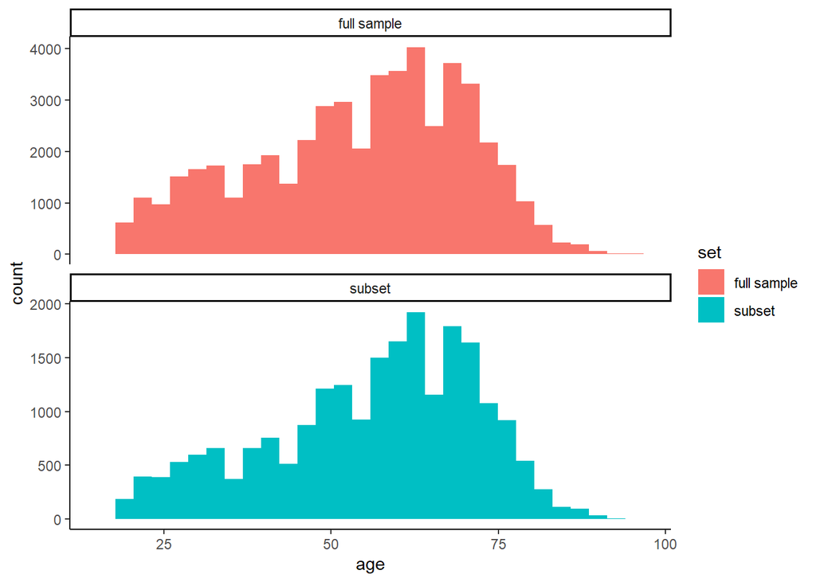

```r
ggplot(dat_plot, aes(x = age, fill = set)) +
  geom_histogram() +
  facet_wrap(~set, ncol = 1, scales = "free_y") +
  theme_classic()
```

Migration.

```r
data.frame(rbind(summary(full_sample$etn_herkomst), summary(subset$etn_herkomst))) |> knitr::kable()
```

| Nederlandse_achtergrond | Westerse_migratieachtergrond | Niet_westerse_migratieachtergrond |
| --- | --- | --- |
| 43350 | 5024 | 2099 |
| 19289 | 2163 | 618 |

```r
table(full_sample$etn_herkomst)/nrow(full_sample)
```

```
          Nederlandse_achtergrond      Westerse_migratieachtergrond
                       0.85887504                        0.09953837
Niet_westerse_migratieachtergrond
                       0.04158659
```

```r
table(subset$etn_herkomst)/nrow(subset)
```

```
          Nederlandse_achtergrond      Westerse_migratieachtergrond
                       0.87399184                        0.09800634
Niet_westerse_migratieachtergrond
                       0.02800181
```

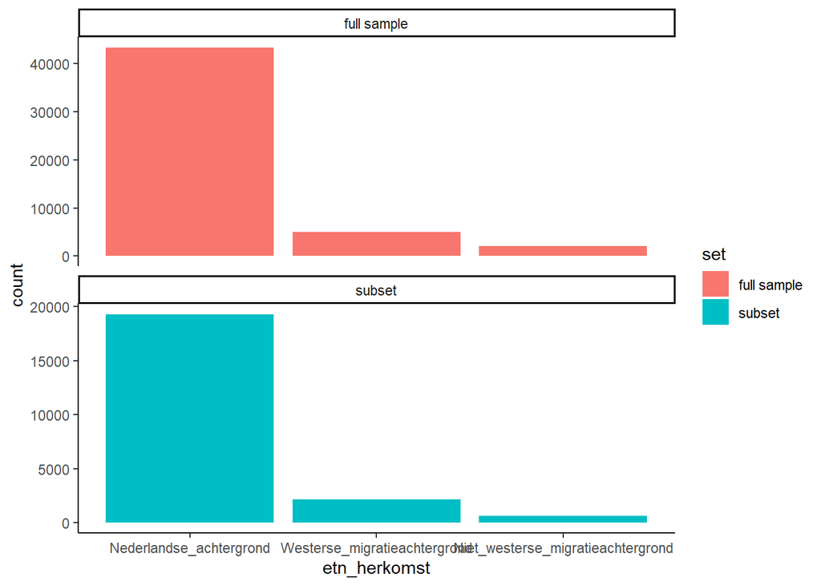

```r
ggplot(dat_plot, aes(x = etn_herkomst, fill = set)) +
  geom_bar() +
  facet_wrap(~set, ncol = 1, scales = "free_y") +
  theme_classic()
```

Education.

```r
data.frame(rbind(summary(full_sample$edu), summary(subset$edu))) |> knitr::kable()
```

| Hoog | Middel | Laag |
| --- | --- | --- |
| 38031 | 9868 | 2574 |
| 16258 | 4776 | 1036 |

```r
table(full_sample$edu)/nrow(full_sample)
```

```
      Hoog     Middel       Laag
0.75349197 0.19551047 0.05099756
```

```r
table(subset$edu)/nrow(subset)
```

```
      Hoog     Middel       Laag
0.73665609 0.21640236 0.04694155
```

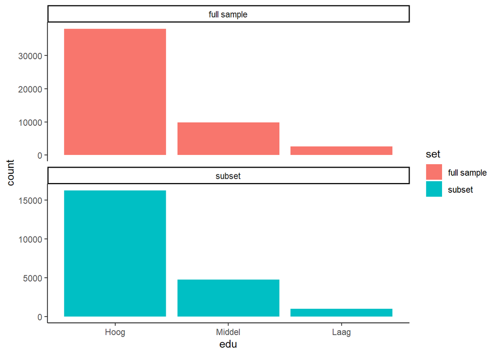

```r
ggplot(dat_plot, aes(x = edu, fill = set)) +
  geom_bar() +
  facet_wrap(~set, ncol = 1, scales = "free_y") +
  theme_classic()
```

Outcome.

```r
mean(full_sample$q60_1)
```

```
[1] 3.672023
```

```r
mean(subset$q60_1)
```

```
[1] 3.731944
```

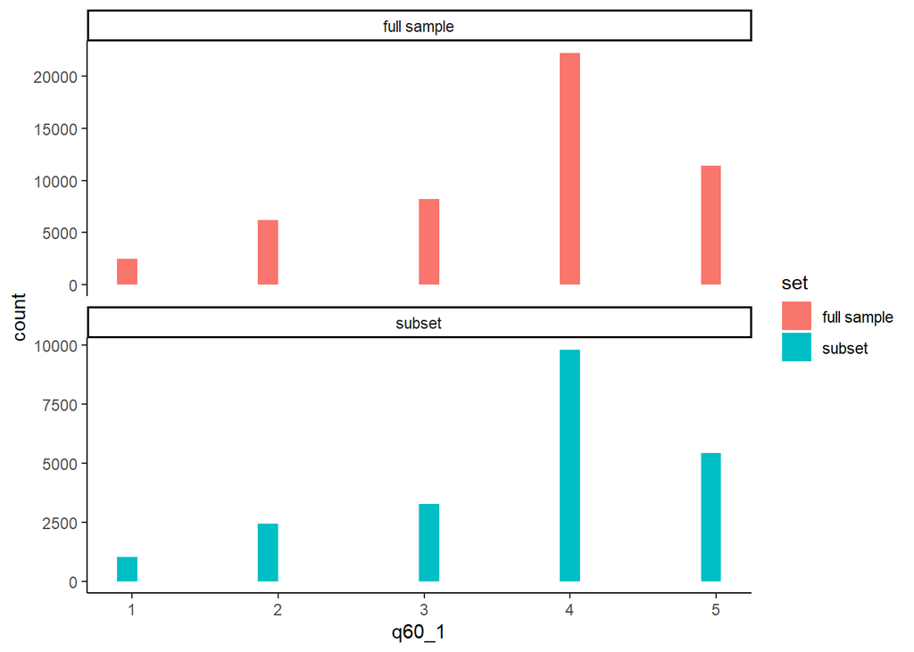

```r
ggplot(dat_plot, aes(x = q60_1, fill = set)) +
  geom_histogram() +
  facet_wrap(~set, ncol = 1, scales = "free_y") +
  theme_classic()
```

# Descriptives table

Descriptives before imputation.

```r
dat_no_imp <- dat_incomplete |>
  haven::as_factor() |>
  filter(id %in% ids_two_measurements) |>
  select(id, wave = METING, sex = SEKSE, age = GEBOORTEJAAR, ethn = ETN_HERKOMST, edu)
# fix age categories
dat_no_imp$age <- 2020 - dat_no_imp$age
dat_no_imp$age_cat <- NA
dat_no_imp[dat_no_imp$age < 35, "age_cat"] <- "18-34"
dat_no_imp[dat_no_imp$age >= 35 & dat_no_imp$age < 50, "age_cat"] <- "35-49"
dat_no_imp[dat_no_imp$age >= 50 & dat_no_imp$age < 65, "age_cat"] <- "50-64"
dat_no_imp[dat_no_imp$age >= 65, "age_cat"] <- "65+"
dat_no_imp$age_cat <- factor(dat_no_imp$age_cat, levels = c("18-34", "35-49", "50-64", "65+"))
# fix edu categories
dat_no_imp$edu_cat <- NA
dat_no_imp[as.numeric(dat_no_imp$edu) > 5, "edu_cat"] <- "low"
dat_no_imp[as.numeric(dat_no_imp$edu) > 2 & as.numeric(dat_no_imp$edu) < 6, "edu_cat"] <- "middle"
dat_no_imp[as.numeric(dat_no_imp$edu) < 3, "edu_cat"] <- "high"

# descriptives
tab_by_wave <- dat_no_imp |>
  select(-id, -age) |>
  gtsummary::tbl_summary(by = wave)

# save table
tab_by_wave %>%
  gtsummary::as_tibble() %>%
  writexl::write_xlsx(., "descriptives_by_wave.xlsx")

tab_by_wave
```

| **Characteristic** | **1** N = 5,269<sup>1</sup> | **2** N = 14,298<sup>1</sup> | **3** N = 15,480<sup>1</sup> | **4 post** N = 17,496<sup>1</sup> | **5** N = 14,772<sup>1</sup> |
| --- | --- | --- | --- | --- | --- |
| GESLACHT |  |  |  |  |  |
| man | 3,165 (60%) | 8,726 (61%) | 9,563 (62%) | 11,111 (64%) | 9,433 (64%) |
| vrouw | 2,104 (40%) | 5,572 (39%) | 5,917 (38%) | 6,385 (36%) | 5,339 (36%) |
| ethn |  |  |  |  |  |
| Nederlandse achtergrond | 4,667 (89%) | 12,566 (88%) | 13,576 (88%) | 15,333 (88%) | 12,943 (88%) |
| Westerste migratieachtergrond | 504 (9.6%) | 1,428 (10.0%) | 1,550 (10%) | 1,689 (9.7%) | 1,442 (9.8%) |
| Niet-Westerse migratie-achtergrond | 98 (1.9%) | 304 (2.1%) | 354 (2.3%) | 474 (2.7%) | 387 (2.6%) |
| Wat is de hoogste opleiding die u heeft afgemaakt? |  |  |  |  |  |
| WO doctoraal of master | 1,043 (20%) | 3,831 (27%) | 4,188 (27%) | 4,639 (27%) | 3,869 (26%) |
| HBO/WO bachelor of kandidaats | 1,419 (27%) | 4,237 (30%) | 4,608 (30%) | 5,188 (30%) | 4,333 (29%) |
| HAVO/VWO bovenbouw, WO/HBO propedeuse | 1,138 (22%) | 2,407 (17%) | 2,583 (17%) | 3,033 (17%) | 2,518 (17%) |
| MBO 2-3-4, of MBO voor 1998 | 1,073 (20%) | 2,365 (17%) | 2,438 (16%) | 2,682 (15%) | 2,403 (16%) |
| Eerste drie jaar HAVO/VWO, MAVO, VMBO (theoretisch en gemengde leerweg) | 261 (5.0%) | 665 (4.7%) | 767 (5.0%) | 970 (5.5%) | 795 (5.4%) |
| MBO 1, LBO, VBO, VMBO (kader- en beroepsgerichte leerweg) | 316 (6.0%) | 732 (5.1%) | 833 (5.4%) | 913 (5.2%) | 787 (5.3%) |
| Geen onderwijs/basisonderwijs | 19 (0.4%) | 61 (0.4%) | 63 (0.4%) | 71 (0.4%) | 67 (0.5%) |
| age_cat |  |  |  |  |  |
| 18-34 | 580 (11%) | 1,570 (11%) | 1,870 (12%) | 2,024 (12%) | 1,462 (9.9%) |
| 35-49 | 1,044 (20%) | 2,387 (17%) | 2,647 (17%) | 2,908 (17%) | 2,346 (16%) |
| 50-64 | 1,835 (35%) | 4,937 (35%) | 5,272 (34%) | 6,139 (35%) | 5,310 (36%) |
| 65+ | 1,810 (34%) | 5,404 (38%) | 5,691 (37%) | 6,425 (37%) | 5,654 (38%) |
| edu_cat |  |  |  |  |  |
| high | 2,462 (47%) | 8,068 (56%) | 8,796 (57%) | 9,827 (56%) | 8,202 (56%) |
| low | 335 (6.4%) | 793 (5.5%) | 896 (5.8%) | 984 (5.6%) | 854 (5.8%) |
| middle | 2,472 (47%) | 5,437 (38%) | 5,788 (37%) | 6,685 (38%) | 5,716 (39%) |

<sup>1</sup> n (%)

Descriptives of unique respondents.

```r
dat_unique <- dat_no_imp[!duplicated(dat_no_imp[,1]),]
tab_overall <- dat_unique |>
  select(-id, -age, -wave) |>
  gtsummary::tbl_summary()

# save table
tab_overall %>%
  gtsummary::as_tibble() %>%
  writexl::write_xlsx(., "descriptives_overall.xlsx")
```

How many measurements do these cases have?

```r
measurements_per_id <- dat_no_imp %>%
  group_by(id) %>%
  summarise(n = n())
measurements_per_id$n |> table() |> knitr::kable()
```

| Var1 | Freq |
| --- | --- |
| 2 | 8762 |
| 3 | 4782 |
| 4 | 6255 |
| 5 | 2085 |

# Analyses

## Model 1: Intercept and time.

```r
fit <- imp_jr %>%
  map(~.x %$% lme4::lmer(
    q60_1 ~ (1 | id) + time_jr,
    weights = .x$weegfactor
  ))
```

AIC

```r
# Summary AIC
fit %>% map( ~ .x %>% AIC()) %>% unlist() %>% summary()
```

```
   Min. 1st Qu.  Median    Mean 3rd Qu.    Max.
 324085  325711  326531  327620  327643  336963
```

Results

```r
# Pooled imputations
results_vert <-
  mitml::testEstimates(as.mitml.result(fit), extra.pars = TRUE)
knitr::kable(round(results_vert$estimates[, c("Estimate", "Std.Error", "P(>|t|)")], 3))
```

|  | Estimate | Std.Error | P(>\|t\|) |
| --- | --- | --- | --- |
| (Intercept) | 3.791 | 0.026 | 0 |
| time_jr | -0.630 | 0.026 | 0 |

```r
knitr::kable(round(results_vert$extra.pars, 3))
```

|  | Estimate |
| --- | --- |
| Intercept~~Intercept\|id | 0.816 |
| Residual~~Residual | 0.279 |
| ICC\|id | 0.745 |

```r
# Save coefficients as csv
table_data <- tibble::rownames_to_column(as.data.frame(results_vert$estimates[, c("Estimate", "Std.Error", "P(>|t|)")]), var = "Predictor")
write.csv2(table_data, file = "../Results/CoefficientsModel1v2.csv", row.names = FALSE)
```

## Model 2: Intercept, time, time-invariant variables.

```r
fit <- imp_jr %>%
  map(~.x %$% lme4::lmer(
    q60_1 ~ (1 | id) + time_jr +
      age + sekse + etn_herkomst + edu + huis,
    weights = .x$weegfactor
  ))
```

AIC

```r
# Summary AIC
fit %>% map( ~ .x %>% AIC()) %>% unlist() %>% summary()
```

```
   Min. 1st Qu.  Median    Mean 3rd Qu.    Max.
 323152  324661  325459  326704  326825  336218
```

Results

```r
# Pooled imputations
results_vert <-
  mitml::testEstimates(as.mitml.result(fit), extra.pars = TRUE)
knitr::kable(round(results_vert$estimates[, c("Estimate", "Std.Error", "P(>|t|)")], 3))
```

|  | Estimate | Std.Error | P(>\|t\|) |
| --- | --- | --- | --- |
| (Intercept) | 3.971 | 0.185 | 0.000 |
| time_jr | -0.630 | 0.026 | 0.000 |
| age | -0.003 | 0.003 | 0.387 |
| sekseVrouw | 0.007 | 0.014 | 0.599 |
| etn_herkomstWesterse_migratieachtergrond | -0.039 | 0.024 | 0.107 |
| etn_herkomstNiet_westerse_migratieachtergrond | -0.071 | 0.042 | 0.092 |
| eduMiddel | -0.379 | 0.017 | 0.000 |
| eduLaag | -0.520 | 0.034 | 0.000 |
| huisAlleenstaand_met_kinderen | -0.098 | 0.038 | 0.011 |
| huisSamenwonend_met_partner_met_thuiswonende_kinderen | 0.134 | 0.020 | 0.000 |
| huisSamenwonend_met_partner_zonder_thuiswonende_kinderen | 0.147 | 0.018 | 0.000 |
| huisAnders | -0.007 | 0.034 | 0.829 |

```r
knitr::kable(round(results_vert$extra.pars, 3))
```

|  | Estimate |
| --- | --- |
| Intercept~~Intercept\|id | 0.772 |
| Residual~~Residual | 0.279 |
| ICC\|id | 0.735 |

```r
# Save coefficients as csv
table_data <- tibble::rownames_to_column(as.data.frame(results_vert$estimates[, c("Estimate", "Std.Error", "P(>|t|)")]), var = "Predictor")
write.csv2(table_data, file = "../Results/CoefficientsModel2v2.csv", row.names = FALSE)
```

## Model 3: Intercept, time, all explanatory variables.

```r
fit <- imp_jr %>%
  map(~.x %$% lme4::lmer(
    q60_1 ~ (1 | id) + time_jr +
      age + sekse + etn_herkomst + edu + huis +
      gezo + rond + drei + onvr,
    weights = .x$weegfactor
  ))
```

AIC

```r
# Summary AIC
fit %>% map( ~ .x %>% AIC()) %>% unlist() %>% summary()
```

```
   Min. 1st Qu.  Median    Mean 3rd Qu.    Max.
 314591  315934  316687  317810  318268  325973
```

Results

```r
# Pooled imputations
results_vert <-
  mitml::testEstimates(as.mitml.result(fit), extra.pars = TRUE)
knitr::kable(round(results_vert$estimates[, c("Estimate", "Std.Error", "P(>|t|)")], 3))
```

|  | Estimate | Std.Error | P(>\|t\|) |
| --- | --- | --- | --- |
| (Intercept) | 4.639 | 0.189 | 0.000 |
| time_jr | -0.528 | 0.025 | 0.000 |
| age | -0.004 | 0.003 | 0.110 |
| sekseVrouw | -0.006 | 0.013 | 0.658 |
| etn_herkomstWesterse_migratieachtergrond | -0.038 | 0.022 | 0.082 |
| etn_herkomstNiet_westerse_migratieachtergrond | -0.072 | 0.038 | 0.056 |
| eduMiddel | -0.284 | 0.017 | 0.000 |
| eduLaag | -0.371 | 0.030 | 0.000 |
| huisAlleenstaand_met_kinderen | -0.075 | 0.035 | 0.030 |
| huisSamenwonend_met_partner_met_thuiswonende_kinderen | 0.098 | 0.018 | 0.000 |
| huisSamenwonend_met_partner_zonder_thuiswonende_kinderen | 0.089 | 0.017 | 0.000 |
| huisAnders | -0.018 | 0.030 | 0.564 |
| gezo | -0.070 | 0.005 | 0.000 |
| rond | -0.051 | 0.007 | 0.000 |
| drei | 0.060 | 0.013 | 0.001 |
| onvr | -0.237 | 0.014 | 0.000 |

```r
knitr::kable(round(results_vert$extra.pars, 3))
```

|  | Estimate |
| --- | --- |
| Intercept~~Intercept\|id | 0.597 |
| Residual~~Residual | 0.265 |
| ICC\|id | 0.692 |

```r
# Save coefficients as csv
table_data <- tibble::rownames_to_column(as.data.frame(results_vert$estimates[, c("Estimate", "Std.Error", "P(>|t|)")]), var = "Predictor")
write.csv2(table_data, file = "../Results/CoefficientsModel3v2.csv", row.names = FALSE)
```

## Model 4: Intercept, time, all explanatory variables and interaction effects with time-invariant variables.

```r
fit <- imp_jr %>%
  map(
    ~ .x %$% lme4::lmer(
      q60_1 ~ (1 | id) + time_jr +
        age + sekse + etn_herkomst + edu + huis +
        gezo + rond + drei + onvr +
        time_jr:age + time_jr:sekse + time_jr:etn_herkomst + time_jr:edu + time_jr:huis,
      weights = .x$weegfactor
    )
  )
```

AIC

```r
# Summary AIC
fit %>% map( ~ .x %>% AIC()) %>% unlist() %>% summary()
```

```
   Min. 1st Qu.  Median    Mean 3rd Qu.    Max.
 314563  315940  316616  317693  318202  325403
```

Results

```r
# Pooled imputations
results_vert <-
  mitml::testEstimates(as.mitml.result(fit), extra.pars = TRUE)
knitr::kable(round(results_vert$estimates[, c("Estimate", "Std.Error", "P(>|t|)")], 3))
```

|  | Estimate | Std.Error | P(>\|t\|) |
| --- | --- | --- | --- |
| (Intercept) | 4.584 | 0.237 | 0.000 |
| time_jr | -0.438 | 0.102 | 0.002 |
| age | -0.003 | 0.003 | 0.340 |
| sekseVrouw | 0.016 | 0.019 | 0.409 |
| etn_herkomstWesterse_migratieachtergrond | -0.036 | 0.032 | 0.269 |
| etn_herkomstNiet_westerse_migratieachtergrond | -0.120 | 0.054 | 0.031 |
| eduMiddel | -0.294 | 0.018 | 0.000 |
| eduLaag | -0.426 | 0.035 | 0.000 |
| huisAlleenstaand_met_kinderen | -0.089 | 0.050 | 0.085 |
| huisSamenwonend_met_partner_met_thuiswonende_kinderen | 0.114 | 0.020 | 0.000 |
| huisSamenwonend_met_partner_zonder_thuiswonende_kinderen | 0.104 | 0.020 | 0.000 |
| huisAnders | -0.014 | 0.038 | 0.716 |
| gezo | -0.069 | 0.005 | 0.000 |
| rond | -0.051 | 0.007 | 0.000 |
| drei | 0.059 | 0.013 | 0.001 |
| onvr | -0.239 | 0.014 | 0.000 |
| time_jr:age | -0.002 | 0.002 | 0.340 |
| time_jr:sekseVrouw | -0.034 | 0.023 | 0.173 |
| time_jr:etn_herkomstWesterse_migratieachtergrond | -0.003 | 0.031 | 0.922 |
| time_jr:etn_herkomstNiet_westerse_migratieachtergrond | 0.074 | 0.053 | 0.194 |
| time_jr:eduMiddel | 0.017 | 0.013 | 0.202 |
| time_jr:eduLaag | 0.086 | 0.038 | 0.045 |
| time_jr:huisAlleenstaand_met_kinderen | 0.021 | 0.051 | 0.685 |
| time_jr:huisSamenwonend_met_partner_met_thuiswonende_kinderen | -0.025 | 0.013 | 0.063 |
| time_jr:huisSamenwonend_met_partner_zonder_thuiswonende_kinderen | -0.023 | 0.020 | 0.282 |
| time_jr:huisAnders | -0.006 | 0.033 | 0.859 |

```r
knitr::kable(round(results_vert$extra.pars, 3))
```

|  | Estimate |
| --- | --- |
| Intercept~~Intercept\|id | 0.597 |
| Residual~~Residual | 0.265 |
| ICC\|id | 0.692 |

```r
# Save coefficients as csv
table_data <- tibble::rownames_to_column(as.data.frame(results_vert$estimates[, c("Estimate", "Std.Error", "P(>|t|)")]), var = "Predictor")
write.csv2(table_data, file = "../Results/CoefficientsModel4v2.csv", row.names = FALSE)
```

```r
fit <- imp_jr %>%
  map(~.x %$% lme4::lmer(
    q60_1 ~ (1 | id) + time_jr + age + sekse + etn_herkomst + edu + huis +
        gezo + rond + drei + onvr +
        time_jr:age + time_jr:sekse + time_jr:etn_herkomst + time_jr:edu + time_jr:huis +
        time_jr:gezo + time_jr:rond + time_jr:drei + time_jr:onvr,
    weights = .x$weegfactor
  ))

fit <- imp_jr %>%
  map(~.x %$% lme4::lmer(
    q60_1 ~ (1 | id) + time_jr + I(time_jr)^2,
    weights = .x$weegfactor
  ))
```

[output not shown]

AIC

```r
# Summary AIC
fit %>% map( ~ .x %>% AIC()) %>% unlist() %>% summary()
```

```
   Min. 1st Qu.  Median    Mean 3rd Qu.    Max.
 324085  325711  326531  327620  327643  336963
```

Results

```r
# Pooled imputations
results_vert <-
  mitml::testEstimates(as.mitml.result(fit), extra.pars = TRUE)
knitr::kable(round(results_vert$estimates[, c("Estimate", "Std.Error", "P(>|t|)")], 3))
```

|  | Estimate | Std.Error | P(>\|t\|) |
| --- | --- | --- | --- |
| (Intercept) | 3.791 | 0.026 | 0 |
| time_jr | -0.630 | 0.026 | 0 |

```r
knitr::kable(round(results_vert$extra.pars, 3))
```

|  | Estimate |
| --- | --- |
| Intercept~~Intercept\|id | 0.816 |
| Residual~~Residual | 0.279 |
| ICC\|id | 0.745 |

```r
# Save coefficients as csv
table_data <- tibble::rownames_to_column(as.data.frame(results_vert$estimates[, c("Estimate", "Std.Error", "P(>|t|)")]), var = "Predictor")
table_data <- mutate(table_data, sig = ifelse(table_data$`P(>|t|)` < 0.05, "*", ""))
write.csv2(table_data, file = "../Results/CoefficientsModel5v2.csv", row.names = FALSE)
```

# Analyses with new weights

## Load new data

```r
library(haven)
Alle_metingen_lang_bestand_REWEIGHTED_toshare_240814 <- read_sav("../Data/Alle metingen_lang bestand_REWEIGHTED_toshare_240814.sav")
View(Alle_metingen_lang_bestand_REWEIGHTED_toshare_240814)
```

## Model 1: Intercept and time.

```r
fit <- imp_jr %>%
  map(~.x %$% lme4::lmer(
    q60_1 ~ (1 | id) + time_jr,
    weights = .x$weegfactor
  ))
```

AIC

```r
# Summary AIC
fit %>% map( ~ .x %>% AIC()) %>% unlist() %>% summary()
```

```
   Min. 1st Qu.  Median    Mean 3rd Qu.    Max.
 324085  325711  326531  327620  327643  336963
```

Results

```r
# Pooled imputations
results_vert <-
  mitml::testEstimates(as.mitml.result(fit), extra.pars = TRUE)
knitr::kable(round(results_vert$estimates[, c("Estimate", "Std.Error", "P(>|t|)")], 3))
```

|  | Estimate | Std.Error | P(>\|t\|) |
| --- | --- | --- | --- |
| (Intercept) | 3.791 | 0.026 | 0 |
| time_jr | -0.630 | 0.026 | 0 |

```r
knitr::kable(round(results_vert$extra.pars, 3))
```

|  | Estimate |
| --- | --- |
| Intercept~~Intercept\|id | 0.816 |
| Residual~~Residual | 0.279 |
| ICC\|id | 0.745 |

```r
# Save coefficients as csv
table_data <- tibble::rownames_to_column(as.data.frame(results_vert$estimates[, c("Estimate", "Std.Error", "P(>|t|)")]), var = "Predictor")
write.csv2(table_data, file = "../Results/CoefficientsModel1v2.csv", row.names = FALSE)
```

## Model 2: Intercept, time, time-invariant variables.

```r
fit <- imp_jr %>%
  map(~.x %$% lme4::lmer(
    q60_1 ~ (1 | id) + time_jr +
      age + sekse + etn_herkomst + edu + huis,
    weights = .x$weegfactor
  ))
```

AIC

```r
# Summary AIC
fit %>% map( ~ .x %>% AIC()) %>% unlist() %>% summary()
```

```
   Min. 1st Qu.  Median    Mean 3rd Qu.    Max.
 323152  324661  325459  326704  326825  336218
```

Results

```r
# Pooled imputations
results_vert <-
  mitml::testEstimates(as.mitml.result(fit), extra.pars = TRUE)
knitr::kable(round(results_vert$estimates[, c("Estimate", "Std.Error", "P(>|t|)")], 3))
```

|  | Estimate | Std.Error | P(>\|t\|) |
| --- | --- | --- | --- |
| (Intercept) | 3.971 | 0.185 | 0.000 |
| time_jr | -0.630 | 0.026 | 0.000 |
| age | -0.003 | 0.003 | 0.387 |
| sekseVrouw | 0.007 | 0.014 | 0.599 |
| etn_herkomstWesterse_migratieachtergrond | -0.039 | 0.024 | 0.107 |
| etn_herkomstNiet_westerse_migratieachtergrond | -0.071 | 0.042 | 0.092 |
| eduMiddel | -0.379 | 0.017 | 0.000 |
| eduLaag | -0.520 | 0.034 | 0.000 |
| huisAlleenstaand_met_kinderen | -0.098 | 0.038 | 0.011 |
| huisSamenwonend_met_partner_met_thuiswonende_kinderen | 0.134 | 0.020 | 0.000 |
| huisSamenwonend_met_partner_zonder_thuiswonende_kinderen | 0.147 | 0.018 | 0.000 |
| huisAnders | -0.007 | 0.034 | 0.829 |

```r
knitr::kable(round(results_vert$extra.pars, 3))
```

|  | Estimate |
| --- | --- |
| Intercept~~Intercept\|id | 0.772 |
| Residual~~Residual | 0.279 |
| ICC\|id | 0.735 |

```r
# Save coefficients as csv
table_data <- tibble::rownames_to_column(as.data.frame(results_vert$estimates[, c("Estimate", "Std.Error", "P(>|t|)")]), var = "Predictor")
write.csv2(table_data, file = "../Results/CoefficientsModel2v2.csv", row.names = FALSE)
```

## Model 3: Intercept, time, all explanatory variables.

```r
fit <- imp_jr %>%
  map(~.x %$% lme4::lmer(
    q60_1 ~ (1 | id) + time_jr +
      age + sekse + etn_herkomst + edu + huis +
      gezo + rond + drei + onvr,
    weights = .x$weegfactor
  ))
```

AIC

```r
# Summary AIC
fit %>% map( ~ .x %>% AIC()) %>% unlist() %>% summary()
```

```
   Min. 1st Qu.  Median    Mean 3rd Qu.    Max.
 314591  315934  316687  317810  318268  325973
```

Results

```r
# Pooled imputations
results_vert <-
  mitml::testEstimates(as.mitml.result(fit), extra.pars = TRUE)
knitr::kable(round(results_vert$estimates[, c("Estimate", "Std.Error", "P(>|t|)")], 3))
```

|  | Estimate | Std.Error | P(>\|t\|) |
| --- | --- | --- | --- |
| (Intercept) | 4.639 | 0.189 | 0.000 |
| time_jr | -0.528 | 0.025 | 0.000 |
| age | -0.004 | 0.003 | 0.110 |
| sekseVrouw | -0.006 | 0.013 | 0.658 |
| etn_herkomstWesterse_migratieachtergrond | -0.038 | 0.022 | 0.082 |
| etn_herkomstNiet_westerse_migratieachtergrond | -0.072 | 0.038 | 0.056 |
| eduMiddel | -0.284 | 0.017 | 0.000 |
| eduLaag | -0.371 | 0.030 | 0.000 |
| huisAlleenstaand_met_kinderen | -0.075 | 0.035 | 0.030 |
| huisSamenwonend_met_partner_met_thuiswonende_kinderen | 0.098 | 0.018 | 0.000 |
| huisSamenwonend_met_partner_zonder_thuiswonende_kinderen | 0.089 | 0.017 | 0.000 |
| huisAnders | -0.018 | 0.030 | 0.564 |
| gezo | -0.070 | 0.005 | 0.000 |
| rond | -0.051 | 0.007 | 0.000 |
| drei | 0.060 | 0.013 | 0.001 |
| onvr | -0.237 | 0.014 | 0.000 |

```r
knitr::kable(round(results_vert$extra.pars, 3))
```

|  | Estimate |
| --- | --- |
| Intercept~~Intercept\|id | 0.597 |
| Residual~~Residual | 0.265 |
| ICC\|id | 0.692 |

```r
# Save coefficients as csv
table_data <- tibble::rownames_to_column(as.data.frame(results_vert$estimates[, c("Estimate", "Std.Error", "P(>|t|)")]), var = "Predictor")
write.csv2(table_data, file = "../Results/CoefficientsModel3v2.csv", row.names = FALSE)
```

## Model 4: Intercept, time, all explanatory variables and interaction effects with time-invariant variables.

```r
fit <- imp_jr %>%
  map(
    ~ .x %$% lme4::lmer(
      q60_1 ~ (1 | id) + time_jr +
        age + sekse + etn_herkomst + edu + huis +
        gezo + rond + drei + onvr +
        time_jr:age + time_jr:sekse + time_jr:etn_herkomst + time_jr:edu + time_jr:huis,
      weights = .x$weegfactor
    )
  )
```

AIC

```r
# Summary AIC
fit %>% map( ~ .x %>% AIC()) %>% unlist() %>% summary()
```

```
   Min. 1st Qu.  Median    Mean 3rd Qu.    Max.
 314563  315940  316616  317693  318202  325403
```

Results

```r
# Pooled imputations
results_vert <-
  mitml::testEstimates(as.mitml.result(fit), extra.pars = TRUE)
knitr::kable(round(results_vert$estimates[, c("Estimate", "Std.Error", "P(>|t|)")], 3))
```

|  | Estimate | Std.Error | P(>\|t\|) |
| --- | --- | --- | --- |
| (Intercept) | 4.584 | 0.237 | 0.000 |
| time_jr | -0.438 | 0.102 | 0.002 |
| age | -0.003 | 0.003 | 0.340 |
| sekseVrouw | 0.016 | 0.019 | 0.409 |
| etn_herkomstWesterse_migratieachtergrond | -0.036 | 0.032 | 0.269 |
| etn_herkomstNiet_westerse_migratieachtergrond | -0.120 | 0.054 | 0.031 |
| eduMiddel | -0.294 | 0.018 | 0.000 |
| eduLaag | -0.426 | 0.035 | 0.000 |
| huisAlleenstaand_met_kinderen | -0.089 | 0.050 | 0.085 |
| huisSamenwonend_met_partner_met_thuiswonende_kinderen | 0.114 | 0.020 | 0.000 |
| huisSamenwonend_met_partner_zonder_thuiswonende_kinderen | 0.104 | 0.020 | 0.000 |
| huisAnders | -0.014 | 0.038 | 0.716 |
| gezo | -0.069 | 0.005 | 0.000 |
| rond | -0.051 | 0.007 | 0.000 |
| drei | 0.059 | 0.013 | 0.001 |
| onvr | -0.239 | 0.014 | 0.000 |
| time_jr:age | -0.002 | 0.002 | 0.340 |
| time_jr:sekseVrouw | -0.034 | 0.023 | 0.173 |
| time_jr:etn_herkomstWesterse_migratieachtergrond | -0.003 | 0.031 | 0.922 |
| time_jr:etn_herkomstNiet_westerse_migratieachtergrond | 0.074 | 0.053 | 0.194 |
| time_jr:eduMiddel | 0.017 | 0.013 | 0.202 |
| time_jr:eduLaag | 0.086 | 0.038 | 0.045 |
| time_jr:huisAlleenstaand_met_kinderen | 0.021 | 0.051 | 0.685 |
| time_jr:huisSamenwonend_met_partner_met_thuiswonende_kinderen | -0.025 | 0.013 | 0.063 |
| time_jr:huisSamenwonend_met_partner_zonder_thuiswonende_kinderen | -0.023 | 0.020 | 0.282 |
| time_jr:huisAnders | -0.006 | 0.033 | 0.859 |

```r
knitr::kable(round(results_vert$extra.pars, 3))
```

|  | Estimate |
| --- | --- |
| Intercept~~Intercept\|id | 0.597 |
| Residual~~Residual | 0.265 |
| ICC\|id | 0.692 |

```r
# Save coefficients as csv
table_data <- tibble::rownames_to_column(as.data.frame(results_vert$estimates[, c("Estimate", "Std.Error", "P(>|t|)")]), var = "Predictor")
write.csv2(table_data, file = "../Results/CoefficientsModel4v2.csv", row.names = FALSE)
```

## Model 5: Intercept, time, all explanatory variables and all interaction effects.

```r
fit <- imp_jr %>%
  map(~.x %$% lme4::lmer(
    q60_1 ~ (1 | id) + time_jr + age + sekse + etn_herkomst + edu + huis +
        gezo + rond + drei + onvr +
        time_jr:age + time_jr:sekse + time_jr:etn_herkomst + time_jr:edu + time_jr:huis +
        time_jr:gezo + time_jr:rond + time_jr:drei + time_jr:onvr,
    weights = .x$weegfactor
  ))
```

AIC

```r
# Summary AIC
fit %>% map( ~ .x %>% AIC()) %>% unlist() %>% summary()
```

```
   Min. 1st Qu.  Median    Mean 3rd Qu.    Max.
 314492  315793  316532  317597  318146  325291
```

Results

```r
# Pooled imputations
results_vert <-
  mitml::testEstimates(as.mitml.result(fit), extra.pars = TRUE)
knitr::kable(round(results_vert$estimates[, c("Estimate", "Std.Error", "P(>|t|)")], 3))
```

|  | Estimate | Std.Error | P(>\|t\|) |
| --- | --- | --- | --- |
| (Intercept) | 4.587 | 0.228 | 0.000 |
| time_jr | -0.422 | 0.101 | 0.002 |
| age | -0.003 | 0.004 | 0.405 |
| sekseVrouw | 0.019 | 0.019 | 0.328 |
| etn_herkomstWesterse_migratieachtergrond | -0.034 | 0.032 | 0.300 |
| etn_herkomstNiet_westerse_migratieachtergrond | -0.119 | 0.054 | 0.034 |
| eduMiddel | -0.297 | 0.018 | 0.000 |
| eduLaag | -0.429 | 0.036 | 0.000 |
| huisAlleenstaand_met_kinderen | -0.091 | 0.051 | 0.083 |
| huisSamenwonend_met_partner_met_thuiswonende_kinderen | 0.115 | 0.020 | 0.000 |
| huisSamenwonend_met_partner_zonder_thuiswonende_kinderen | 0.103 | 0.020 | 0.000 |
| huisAnders | -0.014 | 0.038 | 0.708 |
| gezo | -0.062 | 0.012 | 0.000 |
| rond | -0.062 | 0.011 | 0.000 |
| drei | 0.039 | 0.014 | 0.017 |
| onvr | -0.218 | 0.013 | 0.000 |
| time_jr:age | -0.002 | 0.002 | 0.210 |
| time_jr:sekseVrouw | -0.039 | 0.024 | 0.129 |
| time_jr:etn_herkomstWesterse_migratieachtergrond | -0.007 | 0.031 | 0.830 |
| time_jr:etn_herkomstNiet_westerse_migratieachtergrond | 0.072 | 0.053 | 0.206 |
| time_jr:eduMiddel | 0.023 | 0.014 | 0.106 |
| time_jr:eduLaag | 0.093 | 0.040 | 0.039 |
| time_jr:huisAlleenstaand_met_kinderen | 0.024 | 0.052 | 0.649 |
| time_jr:huisSamenwonend_met_partner_met_thuiswonende_kinderen | -0.025 | 0.013 | 0.057 |
| time_jr:huisSamenwonend_met_partner_zonder_thuiswonende_kinderen | -0.022 | 0.020 | 0.282 |
| time_jr:huisAnders | -0.004 | 0.034 | 0.906 |
| time_jr:gezo | -0.009 | 0.015 | 0.547 |
| time_jr:rond | 0.018 | 0.010 | 0.093 |
| time_jr:drei | 0.029 | 0.008 | 0.001 |
| time_jr:onvr | -0.036 | 0.013 | 0.014 |

```r
knitr::kable(round(results_vert$extra.pars, 3))
```

|  | Estimate |
| --- | --- |
| Intercept~~Intercept\|id | 0.594 |
| Residual~~Residual | 0.265 |
| ICC\|id | 0.692 |

```r
# Save coefficients as csv
table_data <- tibble::rownames_to_column(as.data.frame(results_vert$estimates[, c("Estimate", "Std.Error", "P(>|t|)")]), var = "Predictor")
table_data <- mutate(table_data, sig = ifelse(table_data$`P(>|t|)` < 0.05, "*", ""))
write.csv2(table_data, file = "../Results/CoefficientsModel5v2.csv", row.names = FALSE)
```

# Additional checks

## Check correlations

Correlation between the outcome and time

```r
map(imp_jr, ~cor(.x$q60_1, .x$meting_mnd))
```

```
$`1`
[1] -0.271584

$`2`
[1] -0.2893033

$`3`
[1] -0.2860082

$`4`
[1] -0.2669937

$`5`
[1] -0.2781054

$`6`
[1] -0.2697279

$`7`
[1] -0.2771439

$`8`
[1] -0.2738753

$`9`
[1] -0.2747219

$`10`
[1] -0.279567
```

## Check means time-varying variables

```r
map(imp_jr, ~.x %>%
        select(meting_mnd, gezo, rond, medi, hulp, eenz, cont, drei, onvr, econ, ment) %>%
        group_by(meting_mnd) %>%
        summarise_all(.funs = mean)) %>%
  Reduce("+", .) / max(imp_post$.imp)
```

[output not shown]